# Evaluation des hypothèses de base du Chapitre 1 sur les données transactionnelles Decentraland sur Opensea

Aurélien Yannick Simo Fotso

Dans ce document, nous examinons via les données la vraisemblance des hypothèses de base du chapitre 1, à partir des données d’offre et de demande spontanées de parcelles effectuées sur la place de marché NFT, Opensea.

# Préparation des données

## Chargement des données

Nous chargeons premièrement la base de données. Elle comprend:

- **Les offres spontanées et ventes** de parcelles de septembre 2024 au mai 2026;
- **Les demandes spontanées** de parcelles de septembre 2024 à mai 2026;
- **Les prix plancher** quotidiens des parcelles de 2022 à mai 2026;
- **Les données de localisation** de l’ensemble des parcelles Decentraland négociables;
- **Les prix journaliers des cryptomonnaies** utilisées pour la vente de parcelles.

```r
# Memory cleaning
rm(list = ls())

# Set working directory
setwd("C:/Users/aysif/OneDrive - Université Laval/Documents/Recherche/C1/Explore")
```

```r
library(readxl)
library(lubridate)
library(readr)
library(dplyr)

# Listings & Sales
ListingSales <- read_excel(
  "../Donnees/Opensea.xlsx",
  col_types = c(
    "text", "text", "text", "text", "date", "date", "date", "text", "text",
    "text", "text", "text", "text", "text", "text", "text", "text", "text",
    "text", "text", "numeric", "numeric", "text", "text", "numeric", "numeric",
    "text", "text", "text", "text", "text"
  )
)
# Timezone correction of dates columns
ListingSales$update_date <- as.POSIXct(format(ListingSales$update_date), tz = "America/New_York")
attr(ListingSales$update_date, "tzone") <- "UTC"
ListingSales$expiration_date <- as.POSIXct(format(ListingSales$expiration_date), tz = "America/New_York")
attr(ListingSales$expiration_date, "tzone") <- "UTC"
ListingSales$date <- as.POSIXct(format(ListingSales$date), tz = "America/New_York")
attr(ListingSales$date, "tzone") <- "UTC"

# Unsolicited requests for plots
# Bids of `owned` (private) parcels.
Bids <- read_csv(
  "../Donnees/BidsAll.csv",
  col_types = cols(
    asset_id = col_character(), date = col_datetime(format = "%Y-%m-%dT%H:%M:%SZ"),
    start_date = col_datetime(format = "%Y-%m-%dT%H:%M:%SZ"),
    expiration_date = col_datetime(format = "%Y-%m-%dT%H:%M:%SZ")
  )
)
# Bids of all listed parcels (include some non private - districts - parcels)
BidsL <- read_excel(
  "../Donnees/Bids_opl_Opensea.xlsx",
  col_types = c(
    "text", "text", "text", "text", "date", "text", "text", "text",
    "text", "numeric", "numeric", "text", "date", "date"
  )
)
# Merge bids databases
BidsA <- rbind(Bids |> mutate(src="p"), BidsL |> mutate(src="l"))
BidsA <- BidsA |>
  distinct(asset_id, date, bidder, amount, payment_ccy, .keep_all = T) |>
  group_by(asset_id, date, bidder, amount, payment_ccy) |>
  mutate(
    ct = n()
  ) |>
  ungroup() |>
  arrange(dplyr::desc(ct)) |>
  select(-ct, -src)
Bids <- BidsA
rm(list = c("BidsL", "BidsA"))

# Parcels floor prices
FloorPrices <- read_csv(
  "../Donnees/FloorPrices_Opensea.csv",
  col_types = cols(
    date = col_datetime(format = "%Y-%m-%dT%H:%M:%S%z"),
    symbol = col_character()
  )
)

# Parcels spatial prices
Locations <- read_excel(
  "../Donnees/LocationsFull.xlsx",
  col_types = c(
    "numeric", "numeric", "text", "text", "text", "text", "text", "numeric", "numeric", "numeric", "numeric",
    "numeric", "numeric", "numeric", "numeric", "numeric", "numeric", "numeric", "numeric", "text", "numeric",
    "numeric", "numeric", "numeric", "numeric", "numeric", "numeric", "numeric", "numeric", "numeric", "numeric",
    "numeric", "numeric", "numeric", "numeric", "numeric", "numeric", "numeric", "numeric", "numeric", "numeric",
    "numeric", "numeric", "numeric", "numeric", "numeric", "numeric", "numeric", "numeric", "numeric", "numeric",
    "numeric", "numeric", "numeric", "text", "numeric", "numeric", "numeric", "numeric", "numeric", "numeric",
    "numeric", "numeric", "numeric", "numeric", "numeric", "text"
  )
)

# Cryptocurrencies prices
library(quantmod)
cryptos <- c("ETH")
CryptosPrices <- getSymbols(
  paste(cryptos, "USD", sep = "-"),
  src = "yahoo",
  from = "2024-09-01",
  to = "2026-05-16",
  auto.assign = F,
  verbose = T
)
```

```
downloading  ETH-USD .....
```

## Nettoyage de la base de données des demandes spontanées de parcelles

Les demandes spontanées de parcelles (`bids`) désignent les offres initiées par des acheteurs désireux d’acquérir une parcelle donnée, qu’elle soit listée ou pas. Contrairement aux réponses suite à un listing de parcelles, les demandes spontanées sont des signalement d’intention d’achat à un prix fixé par l’acheteur.

Sur les places de marché NFT, on observe un grand nombre de demandes spontanées de parcelles comparé aux offres spontanées. En effet, des individus ou des bots peuvent envoyer des demandes spontanées en masse visant des NFT appartenant à une collection (projet particulier, à l’exemple de Decentraland) particulière, ou posseant des caractéristiques particulières.

Decentraland ne déroge pas à la règle. Les données de demandes spontanées de parcelles dont nous disposons consignent toutes les demandes spontanées de parcelles faites entre le 16 septembre 2024 et le 15 mai 2026. Cela représente plus de 1 300 000 demandes, contre environ 30 000 offres spontanées sur la même période. Nous devons donc nettoyer la base de données de l’activité des bots et des demandeurs compulsifs.

```r
library(dplyr)
```

```r
Bids <- as_tibble(Bids)
str(Bids)
```

```
tibble [1,549,932 × 14] (S3: tbl_df/tbl/data.frame)
 $ bid_id         : chr [1:1549932] "0x3b9c79e6eb058a261006a7317d5c2b63202452416095149db3fcb59fdf7714d6" "0x3264301c5e6a47c4a2050e0ec2249b3f2e95db87834017bfbabcfa8be26bae0a" "0x4cf539ae4564adf4b6871405169d1ef8562361e0aa7d72d42ea2870120dd104e" "0x18ddda75e9a81dd0f296de3a4da9036fd276f5558d042d6a10286f…
 $ metaverse      : chr [1:1549932] "decentraland" "decentraland" "decentraland" "decentraland" ...
 $ asset_contract : chr [1:1549932] "0xf87e31492faf9a91b02ee0deaad50d51d56d5d4d" "0xf87e31492faf9a91b02ee0deaad50d51d56d5d4d" "0xf87e31492faf9a91b02ee0deaad50d51d56d5d4d" "0xf87e31492faf9a91b02ee0deaad50d51d56d5d4d" ...
 $ asset_id       : chr [1:1549932] "1020847100762815390390123822295304634218" "1020847100762815390390123822295304634218" "1020847100762815390390123822295304634218" "1020847100762815390390123822295304634218" ...
 $ date           : POSIXct[1:1549932], format: "2026-05-15 13:18:00" "2026-05-15 13:17:58" "2026-05-14 13:17:51" "2026-05-14 13:17:48" ...
 $ bidder         : chr [1:1549932] "0x6342847aebf7463697c1a082d50836576d6e2dc2" "0x4f66d4d8491d848dbf260e49a483d32932ca5757" "0x6342847aebf7463697c1a082d50836576d6e2dc2" "0x4f66d4d8491d848dbf260e49a483d32932ca5757" ...
 $ source         : chr [1:1549932] "opensea" "opensea" "opensea" "opensea" ...
 $ payment_token  : chr [1:1549932] "0xc02aaa39b223fe8d0a0e5c4f27ead9083c756cc2" "0xc02aaa39b223fe8d0a0e5c4f27ead9083c756cc2" "0xc02aaa39b223fe8d0a0e5c4f27ead9083c756cc2" "0xc02aaa39b223fe8d0a0e5c4f27ead9083c756cc2" ...
 $ payment_ccy    : chr [1:1549932] "WETH" "WETH" "WETH" "WETH" ...
 $ amount         : num [1:1549932] 0.0227 0.0226 0.0225 0.0224 0.0223 0.0222 0.0221 0.022 0.0219 0.0218 ...
 $ amount_usd     : num [1:1549932] 0 0 0 0 0 0 0 0 0 0 ...
 $ bid_type       : chr [1:1549932] "item_offer" "item_offer" "item_offer" "item_offer" ...
 $ start_date     : POSIXct[1:1549932], format: "2026-05-15 13:18:00" "2026-05-15 13:17:58" "2026-05-14 13:17:50" "2026-05-14 13:17:48" ...
 $ expiration_date: POSIXct[1:1549932], format: "2026-05-21 13:18:00" "2026-05-16 13:17:58" "2026-05-20 13:17:50" "2026-05-15 13:17:48" ...
```

### Stratégie de nettoyage de la base de données des demandes spontanées

Notre stratégie de filtrage de l’activité des bots consiste à évaluer pour chaque bidder (acheteur potentiel).

- le nombre de demandes spontanées sur chaque mois;
- le nombre de parcelles demandées sur chaque mois;
- le nombre de demandes moyen par parcelle sur chaque mois,

Ensuite, nous déciderons de purger la base de données des valeurs extrêmes à droite de l’une ou l’autre des quantités ci dessus.

En effet, les bots et les demandeurs compulsifs ont tendance à envoyer des demandes en lots de parcelles répondant à des caractéristiques particulières (proximité à telle ou telle autre aménité), contrairement aux demandeurs normaux, dont l’activité de demande est moins massive.

### Nettoyage effectif

```r
# Bids database treatment
summ_bids <- Bids %>%
  mutate(
    month = lubridate::month(date), # Create month variable column
    year = lubridate::year(date) # Create year variable column
  ) %>%
  group_by(year, month, bidder, asset_id) %>% # Group data by month, bidder and parcel_id
  summarise(
    total_bids = n() # Count total number of bids relative to a triplet (month, bidder, parcel_id)
  ) %>%
  ungroup() %>% # Relax group
  group_by(year, month, bidder) %>% # Group by month and bidder
  summarise(
    avg_monthly_bids = mean(total_bids, na.rm=T), # Count average bids per parcel for a bidder on a month
    tot_monthly_bids = sum(total_bids, na.rm=T), # Count total bids for a bidder on a month
    nb_parcels_bidden = n() # Count number of parcels bidden for a bidder on a month
  ) %>%
  ungroup() # Relax group
```

```r
summ_bids
```

| year | month | bidder | avg_monthly_bids | tot_monthly_bids | nb_parcels_bidden |
| --- | --- | --- | --- | --- | --- |
| 2024 | 9 | 0x03d4fc5865814d24c9f9de2120aaebdf44e9d8de | 2.000000 | 2 | 1 |
| 2024 | 9 | 0x05e5c46f7dbf28b05773a5dae86d6a019f05d301 | 2.500000 | 5 | 2 |
| 2024 | 9 | 0x0bb4eeb8a78e29095fd92595019091cc16ec1244 | 2.000000 | 4 | 2 |
| 2024 | 9 | 0x0f0e80ab7cfb81292ec3d23876c92b630311b473 | 7.405587 | 13256 | 1790 |
| 2024 | 9 | 0x1122090627b3bc98f2a1c5f1eb1ef78d7628f7ac | 1.500000 | 3 | 2 |
| 2024 | 9 | 0x15a2911855184845b5977952262cbb14705a8fbe | 8.146552 | 18900 | 2320 |
| 2024 | 9 | 0x15c1c5d5ac1b8e63461e0d84ed8586d87074a36a | 2.000000 | 2 | 1 |
| 2024 | 9 | 0x253fa2b0b8ea13bc1329d3823a22742e0cdb4e75 | 1.000000 | 2 | 2 |
| 2024 | 9 | 0x2ee4c45af89774c76a8a73178c281089a8771a00 | 1.000000 | 2 | 2 |
| 2024 | 9 | 0x344aa4e182f2798d8c537bc1a4f963de90b5e2d5 | 164.000000 | 164 | 1 |

[output cut: 604 more lines]

Ramenons les données sur une échelle plus globale sur la totalité de l’horizon temporel.

```r
summ_bids_w <- summ_bids |>
  group_by(bidder) |> # Group by bidder
  summarise(
    tot_bids = sum(tot_monthly_bids, na.rm = T), # Sum of total monthly bids over time
    nb_parcels = sum(nb_parcels_bidden, na.rm = T), # Sum of nb of parcels bidden on months over time
    avg_monthly_bids = mean(avg_monthly_bids, na.rm = T) # Average value of monthly bids per parcel over time
  ) |>
  ungroup() |> # Relax group
  arrange(dplyr::desc(nb_parcels)) # Render table by desc order of nb_parcels
```

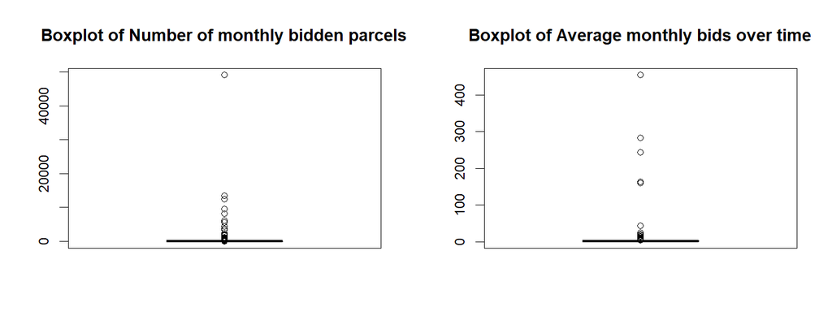

```r
par(mfrow = c(1, 2))
boxplot(summ_bids_w$nb_parcels, main = "Boxplot of Number of monthly bidden parcels")
boxplot(summ_bids_w$avg_monthly_bids, main = "Boxplot of Average monthly bids over time")
```

Les boites à moustache révèlent un nombre important d’outliers à droite pour la moyenne des demandes mensuelles de parcelles et sur le nombre de parcelles demandées par acheteur potentiel. Nous pensons que ces outliers représentent les bots et les demandeurs compulsifs. Nous allons donc les éliminer.

```r
summ_bids <- summ_bids |>
  group_by(year, month) |> # Group by month
  mutate(
    avg_monthly_bids_out = avg_monthly_bids >= quantile(avg_monthly_bids, probs=0.75) + 1.5*IQR(avg_monthly_bids, na.rm = T), # Dummy variable (1 if avg_monthly_bids >= Outlier Upper Bound based on IQR, 0 otherwise)
    nb_parcels_bidden_out = nb_parcels_bidden >= quantile(nb_parcels_bidden, probs=0.75) + 1.5*IQR(nb_parcels_bidden, na.rm = T), # Dummy variable (1 if avg_monthly_bids >= Outlier Upper Bound based on IQR, 0 otherwise),
    bidder_out = as.numeric(avg_monthly_bids_out | nb_parcels_bidden_out), # Dummy variable (1 if at least one of the two variables above is one, 0 otherwise). Will be used to identify bidder to remove from database
    avg_monthly_bids_out = as.numeric(avg_monthly_bids_out),
    nb_parcels_bidden_out = as.numeric(nb_parcels_bidden_out)
  ) |>
  ungroup()
```

```r
# Get bots and compulsive bidders (based on dummy variables defined above)
bidder_to_remove <- unique(summ_bids$bidder[which(summ_bids$bidder_out == 1)])

# Extract bids made by bidders which are not bots and compulsive bidders
FilteredBids <- Bids |>
  filter(!(bidder %in% bidder_to_remove))

# Print Filtered Bids database structure
str(FilteredBids)
```

```
tibble [62,908 × 14] (S3: tbl_df/tbl/data.frame)
 $ bid_id         : chr [1:62908] "0x3b9c79e6eb058a261006a7317d5c2b63202452416095149db3fcb59fdf7714d6" "0x4cf539ae4564adf4b6871405169d1ef8562361e0aa7d72d42ea2870120dd104e" "0x5692848f48023f6cb98ddb6d97ae193dad116d3f436953c2978b95e4f98d5ffe" "0x21073c23b27edcf1a9ebec02893e8f81473104718f56548599d59a16…
 $ metaverse      : chr [1:62908] "decentraland" "decentraland" "decentraland" "decentraland" ...
 $ asset_contract : chr [1:62908] "0xf87e31492faf9a91b02ee0deaad50d51d56d5d4d" "0xf87e31492faf9a91b02ee0deaad50d51d56d5d4d" "0xf87e31492faf9a91b02ee0deaad50d51d56d5d4d" "0xf87e31492faf9a91b02ee0deaad50d51d56d5d4d" ...
 $ asset_id       : chr [1:62908] "1020847100762815390390123822295304634218" "1020847100762815390390123822295304634218" "1020847100762815390390123822295304634218" "1020847100762815390390123822295304634218" ...
 $ date           : POSIXct[1:62908], format: "2026-05-15 13:18:00" "2026-05-14 13:17:51" "2026-05-13 13:17:13" "2026-05-12 13:16:54" ...
 $ bidder         : chr [1:62908] "0x6342847aebf7463697c1a082d50836576d6e2dc2" "0x6342847aebf7463697c1a082d50836576d6e2dc2" "0x6342847aebf7463697c1a082d50836576d6e2dc2" "0x6342847aebf7463697c1a082d50836576d6e2dc2" ...
 $ source         : chr [1:62908] "opensea" "opensea" "opensea" "opensea" ...
 $ payment_token  : chr [1:62908] "0xc02aaa39b223fe8d0a0e5c4f27ead9083c756cc2" "0xc02aaa39b223fe8d0a0e5c4f27ead9083c756cc2" "0xc02aaa39b223fe8d0a0e5c4f27ead9083c756cc2" "0xc02aaa39b223fe8d0a0e5c4f27ead9083c756cc2" ...
 $ payment_ccy    : chr [1:62908] "WETH" "WETH" "WETH" "WETH" ...
 $ amount         : num [1:62908] 0.0227 0.0225 0.0223 0.0221 0.0219 0.0217 0.0215 0.0213 0.0211 0.0209 ...
 $ amount_usd     : num [1:62908] 0 0 0 0 0 0 0 0 0 0 ...
 $ bid_type       : chr [1:62908] "item_offer" "item_offer" "item_offer" "item_offer" ...
 $ start_date     : POSIXct[1:62908], format: "2026-05-15 13:18:00" "2026-05-14 13:17:50" "2026-05-13 13:17:12" "2026-05-12 13:16:54" ...
 $ expiration_date: POSIXct[1:62908], format: "2026-05-21 13:18:00" "2026-05-20 13:17:50" "2026-05-19 13:17:12" "2026-05-18 13:16:54" ...
```

### Résultat du nettoyage

Sur un peu moins d’1 550 000 demandes spontanées, nous avons environ 63 000 demandes spontanées non issues de bots ou de demandeurs compulsifs.

## Lien Localisation - Attention

### Construction de la base de données

Nous mesurons l’attention suscitée par une parcelle par la quantité de demande spontanées sur cette parcelle. A partir de la base de données filtrée des demandes spontanées, nous allons construire deux bases de données :

- Une base de données des demandes spontanées totales sur l’horizon temporelle;
- Une base de données des demandes spontanées mensuelles.

Nous considérons pour chaque base de données deux mesures d’attention:

- Le nombre de demandes spontanées;
- Le nombre de demandeurs spontanées distincts.

```r
library(tidyr)
library(data.table)

# Database of all bids per parcel over time (suffix `w` = Whole)
flt_bids_w <- FilteredBids |>
  group_by(asset_id, bidder) |> # Group by parcel_id and bidder
  summarise(
    n_bids = n() # Count number of bids for a pair (parcel_id, bidder)
  ) |>
  ungroup() |> # Relax group
  group_by(asset_id) |> # Group by parcel_id
  summarise(
    n_bids = sum(n_bids, na.rm=T), # Count total number of bids on parcel_id
    n_bidders = n() # Count total number of distinct bidders
  ) |>
  ungroup() |> # Relax group
  left_join( # Join with Locations database
    Locations |>
      select( # Take only some columns in locations database
        TOKEN_ID, TYPE, DIST_PLAZA_central, DIST_NRS_PLAZA, NAME_NRS_PLAZA, DIST_ROAD,
        DIST_NRS_DISTRICT_CAT, NAME_NRS_DISTRICT_CAT
      ) |>
      mutate(
        IN_DISTRICT = as.numeric(TYPE == "district") # Infer is parcel is in a district or not
      ) |>
      rename(
        asset_id = TOKEN_ID, # Parcel_id
        IDX = IN_DISTRICT, # Parcel is in district ?
        DPC = DIST_PLAZA_central, # Distance to central plaza
        DPX = DIST_NRS_PLAZA, # Distance to neareat peripheral plaza
        NPX = NAME_NRS_PLAZA, # Name of nearest peripheral plaza
        DRD = DIST_ROAD, # Distance to road
        DDX = DIST_NRS_DISTRICT_CAT, # Distance to nearest district
        NDX = NAME_NRS_DISTRICT_CAT # Category of nearest ditrict
      ) |>
      select(-TYPE),
    by = "asset_id"
  )

# Database of all bids per parcel per month (suffix `t` = Temporal)
flt_bids_t <- FilteredBids |>
  mutate(
    month = lubridate::floor_date(date, unit = "month") # Create month variable columns
  ) |>
  group_by(month, asset_id, bidder) |> # Group by month, parcel_id and bidder
  summarise(
    n_bids = n() # Count number of bids for a triplet (month, parcel_id, bidder)
  ) |>
  ungroup() |> # Relax group
  group_by(month, asset_id) |> # Group by month and parcel_id
  summarise(
    n_bids = sum(n_bids, na.rm=T), # Count total number of bids on parcel_id on a month
    n_bidders = n() # Count total number of distinct bidders on a month
  ) |>
  ungroup() |> # Relax group
  right_join( # Join with a panel of all (month, parcel_id) pairs, to avoid missing data of monthly (month, parcel_id) bids
    as_tibble(
      data.table::CJ(
        month = seq( # Sequence of months starting from min database date to max database date
          from = lubridate::floor_date(min(FilteredBids$date), unit = "month"),
          to = lubridate::floor_date(max(FilteredBids$date), unit = "month"),
          by = "month"
        ),
        asset_id = unique(FilteredBids$asset_id) # Unique values of parcel_id
      )
    ),
    by = c("month", "asset_id")
  ) |>
  mutate( # Put 0 for missing data of monthly (month, parcel_id) bids
    n_bids = replace_na(n_bids, 0L),
    n_bidders = replace_na(n_bidders, 0L),
    d_bid = as.numeric(n_bids > 0) # Dummy variable (is 1 if there is a bid for the parcel on a month, 0 otherwise)
  ) |>
  left_join( # Join with Locations database
    Locations |>
      select( # Take only some columns in locations database
        TOKEN_ID, TYPE, DIST_PLAZA_central, DIST_NRS_PLAZA, NAME_NRS_PLAZA, DIST_ROAD,
        DIST_NRS_DISTRICT_CAT, NAME_NRS_DISTRICT_CAT
      ) |>
      mutate(
        IN_DISTRICT = as.numeric(TYPE == "district") # Infer is parcel is in a district or not
      ) |>
      rename(
        asset_id = TOKEN_ID, # Parcel_id
        IDX = IN_DISTRICT, # Parcel is in district ?
        DPC = DIST_PLAZA_central, # Distance to central plaza
        DPX = DIST_NRS_PLAZA, # Distance to neareat peripheral plaza
        NPX = NAME_NRS_PLAZA, # Name of nearest peripheral plaza
        DRD = DIST_ROAD, # Distance to road
        DDX = DIST_NRS_DISTRICT_CAT, # Distance to nearest district
        NDX = NAME_NRS_DISTRICT_CAT # Category of nearest ditrict
      ) |>
      select(-TYPE),
    by = "asset_id"
  )
```

```r
str(flt_bids_w)
```

```
tibble [2,965 × 10] (S3: tbl_df/tbl/data.frame)
 $ asset_id : chr [1:2965] "100" "101" "102" "1020847100762815390390123822295304634218" ...
 $ n_bids   : int [1:2965] 12 12 12 87 9 15 14 107 1 1 ...
 $ n_bidders: int [1:2965] 1 1 1 2 2 3 3 5 1 1 ...
 $ DPC      : num [1:2965] 91 92 93 141 105 ...
 $ DPX      : num [1:2965] 8 9 10 59 23 ...
 $ NPX      : chr [1:2965] "north" "north" "north" "south" ...
 $ DRD      : num [1:2965] 6 7 8 1 1 1 2 3 4 1 ...
 $ DDX      : num [1:2965] 0 0 0 73 72 ...
 $ NDX      : chr [1:2965] "art" "art" "art" "game" ...
 $ IDX      : num [1:2965] 1 1 1 0 0 0 0 0 0 0 ...
```

```r
str(flt_bids_t)
```

```
tibble [62,265 × 12] (S3: tbl_df/tbl/data.frame)
 $ month    : POSIXct[1:62265], format: "2024-09-01" "2024-09-01" "2024-09-01" "2024-09-01" ...
 $ asset_id : chr [1:62265] "1020847100762815390390123822295304634254" "10208471007628153903901238222953046343758" "10548753374549092367364612830384814555214" "10548753374549092367364612830384814555224" ...
 $ n_bids   : int [1:62265] 4 1 2 10 1 4 1 1 1 2 ...
 $ n_bidders: int [1:62265] 1 1 1 3 1 3 1 1 1 1 ...
 $ d_bid    : num [1:62265] 1 1 1 1 1 1 1 1 1 1 ...
 $ DPC      : num [1:62265] 105 71.8 72.1 81.7 159.7 ...
 $ DPX      : num [1:62265] 23 20 21 21 80.1 ...
 $ NPX      : chr [1:62265] "south" "north" "north" "north" ...
 $ DRD      : num [1:62265] 1 15 15 5 22 8 28 25 26 27 ...
 $ DDX      : num [1:62265] 72 2 3 5 0 1 0 0 0 0 ...
 $ NDX      : chr [1:62265] "game" "art" "art" "art" ...
 $ IDX      : num [1:62265] 0 0 0 0 1 0 1 1 1 1 ...
```

### Régressions

```r
source("./models.R")
```

#### Localisation - Demandes spontanées totales

Nous régressons le nombre de demandes spontanées totales (par parcelle) sur les variables de localisation.

```r
# Explained variable: `n_bids` = Number of bids for a parcel
# Regressors:
# - `DPC`: Distance to Central Plaza
# - `DPX`: Distance to closest Peripheral Plaza
# - `NPX`: Name of Peripheral Plaza (north, south, east, west, north-east, south-east, north-west, south-west)
# - `DRD`: Distance to Road
# - `DDX`: Distance to closest District
# - `IDX`: Is Parcel a District Parcel ?

res = lm_model(
  flt_bids_w,
  Y = c("n_bids"),
  X = c("DPC", "DPX", "NPX", "DRD", "DDX", "IDX")
)
summary(res$model)
```

Les régresseurs significatifs sont :

- **La proximité au plaza périphérique sud**: Effet **Positif** sur l’attention (Nombre de demandes spontanées);
- **La distance à la route**: Effet **Négatif** sur l’attention (Nombre de demandes spontanées);
- **L’inclusion dans un district**: Effet **Négatif** sur l’attention (Nombre de demandes spontanées);

Plus une parcelle est proche du sud, d’une route, et non incluse dans un district, plus l’attention (mesurée par le nombre de demandes spontanées de potentiels acheteurs) sera forte.

#### Localisation - Demandeurs distincts total

Nous régressons le nombre de demandeurs distincts total (par parcelle) sur les variables de localisation.

```r
# Explained variable: `n_bidders` = Number of distinct bidders for a parcel
# Regressors:
# - `DPC`: Distance to Central Plaza
# - `DPX`: Distance to closest Peripheral Plaza
# - `NPX`: Name of Peripheral Plaza (north, south, east, west, north-east, south-east, north-west, south-west)
# - `DRD`: Distance to Road
# - `DDX`: Distance to closest District
# - `IDX`: Is Parcel a District Parcel ?

res = lm_model(
  flt_bids_w,
  Y = c("n_bidders"),
  X = c("DPC", "DPX", "NPX", "DRD", "DDX", "IDX")
)
summary(res$model)
```

Les régresseurs significatifs sont :

- **La distance au plaza central**: Effet **Positif** sur l’attention (Nombre de demandeurs distincts);
- **La distance au plaza périphérique le plus proche**: Effet **Négatif** sur l’attention (Nombre de demandeurs distinctss);
- **La proximité aux plazas périphérique nord-ouest, sud et sud-est (diagonale sécondaire)**: Effets **tous Positif** sur l’attention (Nombre de demandeurs distincts);
- **La distance à la route**: Effet **Négatif** sur l’attention (Nombre de demandeurs distincts);
- **L’inclusion dans un district**: Effet **Positif** sur l’attention (Nombre de demandeurs distincts);

Plus une parcelle est éloignée du centre, proche des plazas nord-ouest, sud et sud-est, proche d’une route, et incluse dans un district, plus l’attention (mesurée par le nombre de demandeurs distincts) sera forte.

#### Localisation - Demandes spontanées mensuelles

```r
# Explained variable: `n_bids` = Number of bids for a parcel on a month
# Regressors:
# - `DPC`: Distance to Central Plaza
# - `DPX`: Distance to closest Peripheral Plaza
# - `NPX`: Name of Peripheral Plaza (north, south, east, west, north-east, south-east, north-west, south-west)
# - `DRD`: Distance to Road
# - `DDX`: Distance to closest District
# - `IDX`: Is Parcel a District Parcel ?
# Regression Type : Panel Fixed-Effects
# Fixed Effects: Temporal (Month)
# Error Clustered By: Month

res = felp_model(
  flt_bids_t,
  Y = c("n_bids"),
  X = c("DPC", "DPX", "NPX", "DRD", "DDX", "IDX"),
  # X = c("DPC", "DPX", "NPX", "DRD", "DDX", "NDX"),
  fe = c("month"),
  cl = c("month")
)
res
```

Au seuil de **10%**, les régresseurs significatifs sont :

- **La distance au plaza périphérique le plus proche**: Effet **Négatif** sur l’attention (Nombre de demandes spontanées);
- **La proximité aux plazas périphérique sud et sud-est**: Effets **tous Positif** sur l’attention (Nombre de demandes spontanées);
- **La distance à la route**: Effet **Négatif** sur l’attention (Nombre de demandes spontanées);

Plus une parcelle est proche des plazas sud et sud-est, proche d’une route, plus l’attention (Nombre de demandes spontanées mensuelles) sera forte.

#### Localisation - Demandeurs uniques mensuels

```r
# Explained variable: `n_bidders` = Number of distinct bidders for a parcel on a month
# Regressors:
# - `DPC`: Distance to Central Plaza
# - `DPX`: Distance to closest Peripheral Plaza
# - `NPX`: Name of Peripheral Plaza (north, south, east, west, north-east, south-east, north-west, south-west)
# - `DRD`: Distance to Road
# - `DDX`: Distance to closest District
# - `IDX`: Is Parcel a District Parcel ?
# Regression Type : Panel Fixed-Effects
# Fixed Effects: Temporal (Month)
# Error Clustered By: Month

res = felp_model(
  flt_bids_t,
  Y = c("n_bidders"),
  X = c("DPC", "DPX", "NPX", "DRD", "DDX", "IDX"),
  # X = c("DPC", "DPX", "NPX", "DRD", "DDX", "NDX"),
  fe = c("month"),
  cl = c("month")
)
summary(res)
```

Au seuil de **10%**, les régresseurs significatifs sont :

- **La proximité aux plazas périphérique nord-est et sud-est**: Effets **tous Positif** sur l’attention (Nombre de demandeurs distincts);

Plus une parcelle est proche des plazas nord-est et sud-est, plus l’attention (mesurée par le nombre de demandeurs distincts) sera forte.

#### Localisation - Demande existante mensuelle

```r
# Explained variable: `d_bid` = Dummy variable (1 if parcel has been bidden in a month, 0 otherwise)
# Regressors:
# - `DPC`: Distance to Central Plaza
# - `DPX`: Distance to closest Peripheral Plaza
# - `NPX`: Name of Peripheral Plaza (north, south, east, west, north-east, south-east, north-west, south-west)
# - `DRD`: Distance to Road
# - `DDX`: Distance to closest District
# - `IDX`: Is Parcel a District Parcel ?
# Regression Type : Panel Fixed-Effects
# Fixed Effects: Temporal (Month)
# Error Clustered By: Month

res = felogit_model(
  flt_bids_t,
  Y = c("d_bid"),
  X = c("DPC", "DPX", "NPX", "DRD", "DDX", "IDX"),
  # X = c("DPC", "DPX", "NPX", "DRD", "DDX", "NDX"),
  fe = c("month"),
  cl = c("month")
)
summary(res)
```

Les régresseurs significatifs sont :

- **La proximité aux plazas périphériques nord et nord-est**: Effets **tous Positif** sur l’attention (Demande existante sur un mois);

Plus une parcelle est proche des plazas nord et nord-est, plus l’attention (mesurée par l’existence de la demande de parcelle sur un mois) sera forte.

### Conclusion

Nous notons globalement, contrairement à ce quoi l’on aurait pu s’attendre, que l’éloignement d’une parcelle au centre augmente l’attention portée sur elle. Une parcelle localisée au sud de la carte attire plus d’attention totale, tandis qu’une parcelle localisée au nord attire plus d’attention mensuelle. En outre, quelque soit la position de la parcelle, sa proximité à la route augmente l’attention portée sur elle.